# Coursework 1

Sum Yu Ng

16/03/2021

## Introduction

In this report we will carry out a simulation to investigate how quickly the sample acf and the sample pacf converge to their theoretical values for different n for a particular ARMA(1,2) mode X_t − φ_1*X_t−1 = Z_t − θ_1*Z_t−1 − θ_2*Z_t−2 Rearrange it first X_t = φ_1*X_t−1 + Z_t − θ_1*Z_t−1 − θ_2*Z_t−2

where φ1 = 0.8, θ1 = 0.5, θ2 = 0.4 and σz = 1, and the white noise is normally distributed. Try n = 20, 50, 100, 1000, 10000

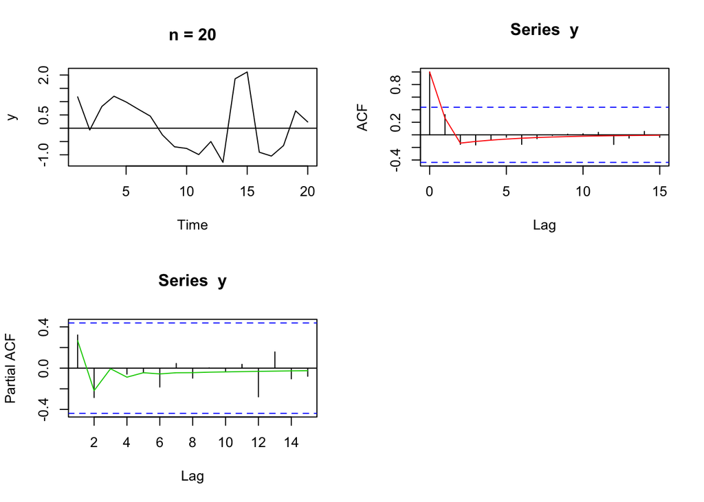

```r
#set seed to ensure all results and figures are reproducible
set.seed(123)
# Split plotting window in three rows
par(mfrow=c(2,2))
phi <- 0.8
theta1 <- 0.5
theta2 <- 0.4
n <- 20
σ <- 1
y = arima.sim(n=n, model=list( ar=c(phi), ma=-c(theta1,theta2) ), sd = σ )
 # plot the time series
ts.plot(y)
abline(h = 0)
title(paste("n =",n))
# plot the acf
#Sample ACF
a<-acf(y,lag.max=15)
# Generate the theoretical ACF with upto lag 15
ta <- ARMAacf(ar=c(phi),ma= -c(theta1,theta2),lag.max=15)
lines(0:15,ta,col=2)
# plot the pacf
p<-pacf(y,lag.max=15)
# Generate the theoretical PACF with upto lag 15
tp<-ARMAacf(ar=c(phi),ma= -c(theta1,theta2),lag.max=15,pacf=TRUE)
lines(1:15,tp,col=3)
```

### Investigation

The sample values are black bars and the theoretical values joined by red line and green line. The sample acf/pacf and theoretical acf/pacf do have quite similar values, especially for lower lags lets see will other simulations have different results.

```r
msa <- mean( (a$acf-ta)**2)
print(c("mean square error of ACF :",msa))
```

```
## [1] "mean square error of ACF :" "0.00314291253520015"
```

```r
msp <- mean( (p$acf-tp)**2)
print(c("mean sqaure error of PACF :",msp))
```

```
## [1] "mean sqaure error of PACF :" "0.00976421805005237"
```

#increasing n we now consider the same plots with n = 20,50, 100, 1000, 10000

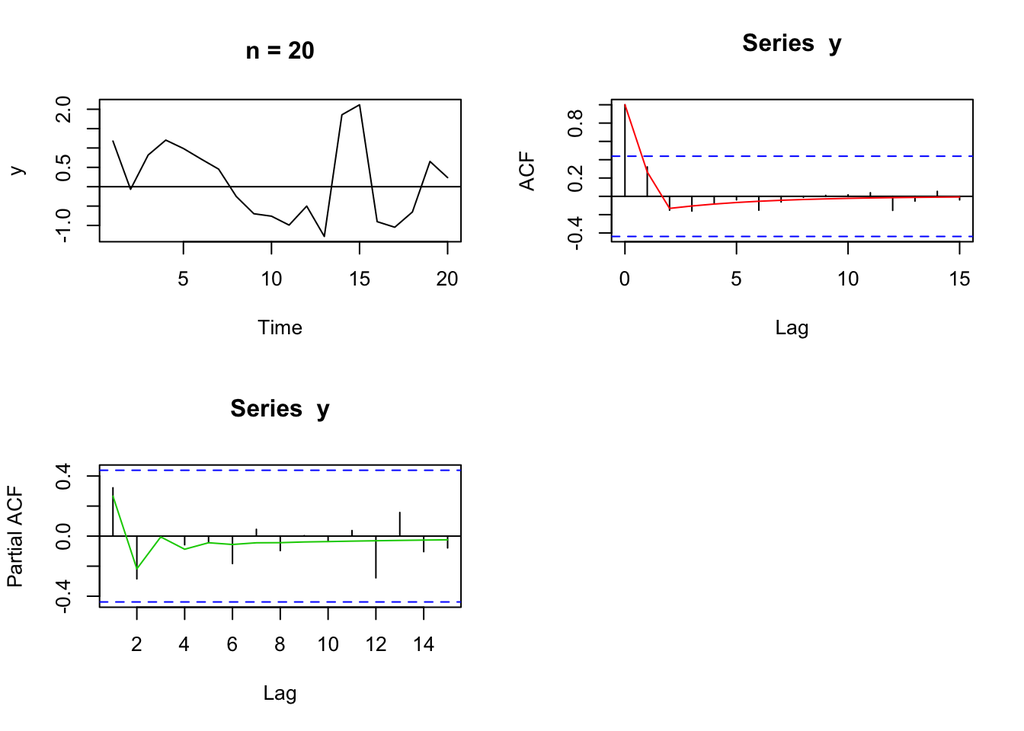

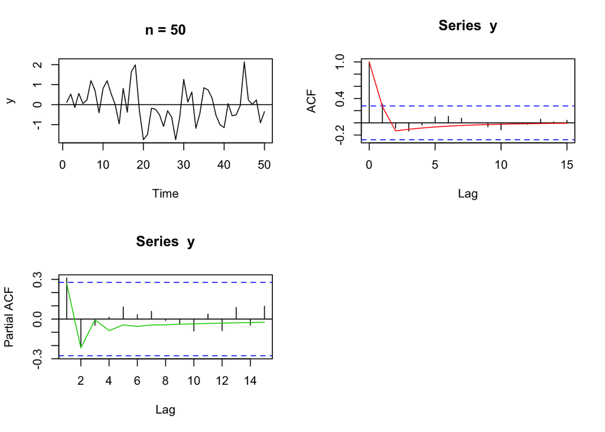

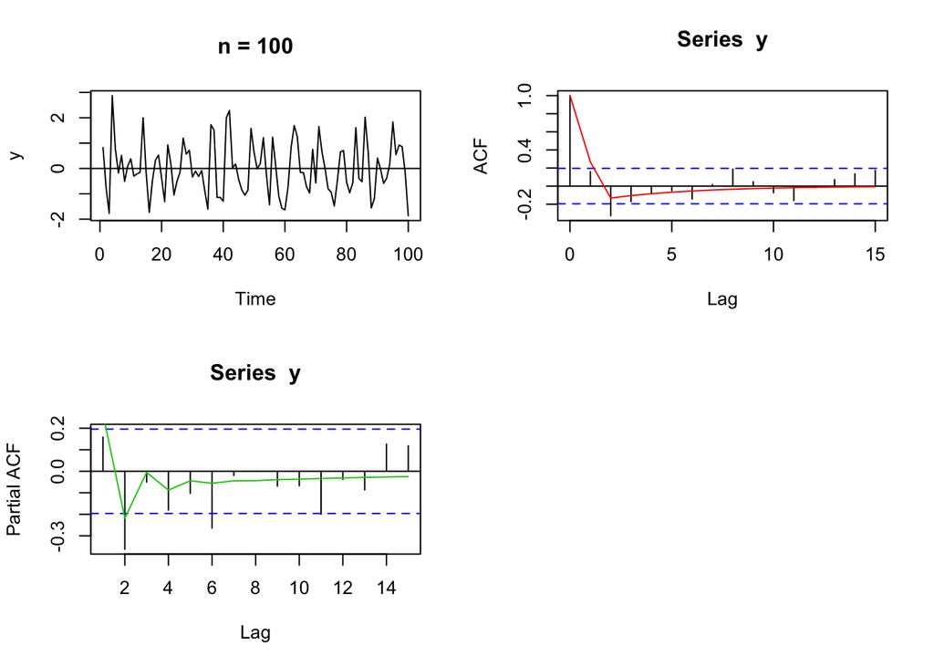

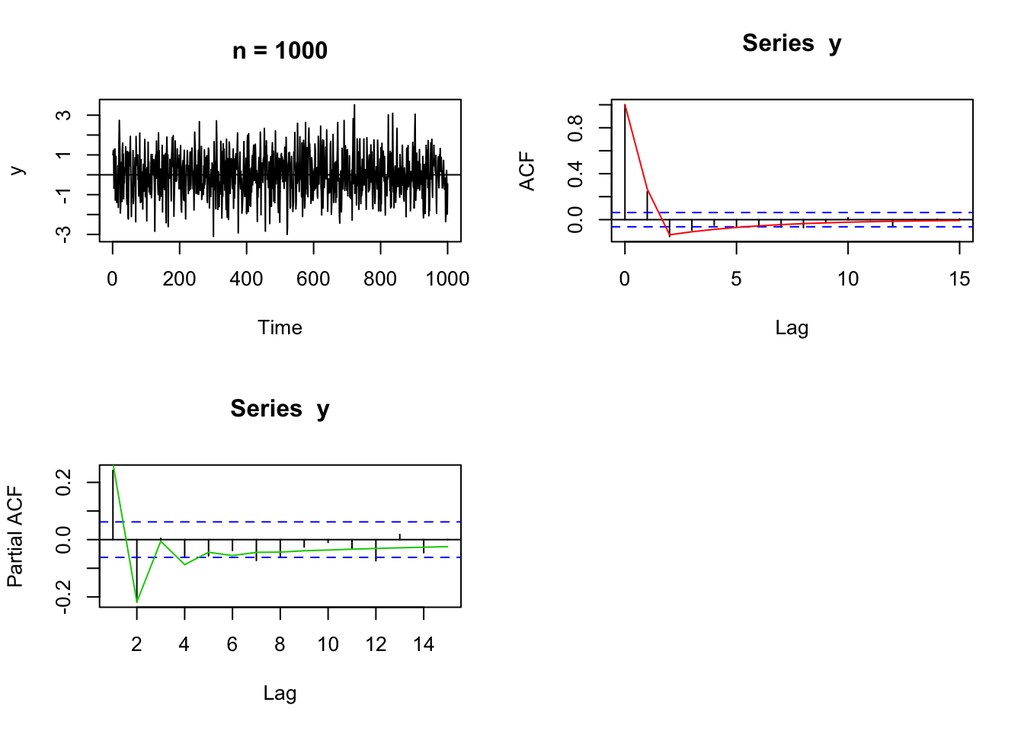

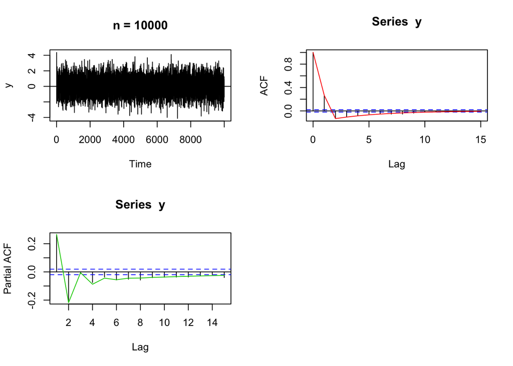

```r
#set seed to ensure all results and figures are reproducible
set.seed(123)
i<-0
#empty lists for storing values later
log_mse_acf <- vector(mode = "list", length = 0)
log_mse_pacf <- vector(mode = "list", length = 0)
mse_acf <- vector(mode = "list", length = 0)
mse_pacf <- vector(mode = "list", length = 0)
for (n in c(20 , 50, 100, 1000, 10000)){
  i <- i + 1
# Split plotting window in 2 rows 2 columns
par(mfrow = c(2,2))
y = arima.sim(n=n, model=list( ar=c(phi), ma=-c(theta1,theta2) ),sd = σ )
# plot the time series
ts.plot(y)
abline(h = 0)
title(paste("n =",n))
# plot the acf
#Sample ACF
a1<-acf(y,lag.max=15)
# Generate the theoretical PACF with upto lag 15
ta1 <- ARMAacf(ar=c(phi),ma= -c(theta1,theta2),lag.max=15)
lines(0:15,ta1,col=2)
# plot the pacf
#Sample PACF
p1<-pacf(y,lag.max=15)
# Generate the theoretical PACF with upto lag 15
tp1<-ARMAacf(ar=c(phi),ma= -c(theta1,theta2),lag.max=15,pacf=TRUE)
lines(1:15,tp1,col=3)
#mean square error of acf
msa1 <- mean((a1$acf-ta1)**2)
#append(log mse so as to benefit the visualisation)
mse_acf <- c(mse_acf,msa1)
log_mse_acf <- c(log_mse_acf,log(msa1))
#mean square error or pacf
msp1 <- mean((p1$acf-tp1)**2)
#append(log mse so as to benefit the visualisation)
mse_pacf <- c(mse_pacf,msp1)
log_mse_pacf <- c(log_mse_pacf,log(msp1))
}
```

```r
#print the mean square error
print(c("mean square error of ACF:",mse_acf))
```

```
## [[1]]
## [1] "mean square error of ACF:"
##
## [[2]]
## [1] 0.003142913
##
## [[3]]
## [1] 0.005869268
##
## [[4]]
## [1] 0.01279531
##
## [[5]]
## [1] 0.0005066461
##
## [[6]]
## [1] 7.05729e-05
```

```r
print(c("mean square error of PACF:",mse_pacf))
```

```
## [[1]]
## [1] "mean square error of PACF:"
##
## [[2]]
## [1] 0.009764218
##
## [[3]]
## [1] 0.006099127
##
## [[4]]
## [1] 0.01125859
##
## [[5]]
## [1] 0.0005946922
##
## [[6]]
## [1] 6.471249e-05
```

### Investigation

We can see that at the when n is getting larger,the sample acf/pacf and theoretical acf/pacf are diverging in the begining and they ultimately converge when n = 100. In terms of mse,the error is increasing when n increases from 20 to 100 when the error is decreasing when n increases from 100 to 10000 which align with the graph for acf.For pacf,it drops first and rises and eventually drops. Next we are going to visualise our results.

```r
#take log on both n and mse as mse is very small
log_n <- c(log(20),log(50),log(100),log(1000),log(10000))
#Visualisation
#log(mse) of ACF vs log(n)
print(c("log(mse) of ACF:",log_mse_acf))
```

```
## [[1]]
## [1] "log(mse) of ACF:"
##
## [[2]]
## [1] -5.762605
##
## [[3]]
## [1] -5.138025
##
## [[4]]
## [1] -4.358677
##
## [[5]]
## [1] -7.587698
##
## [[6]]
## [1] -9.558864
```

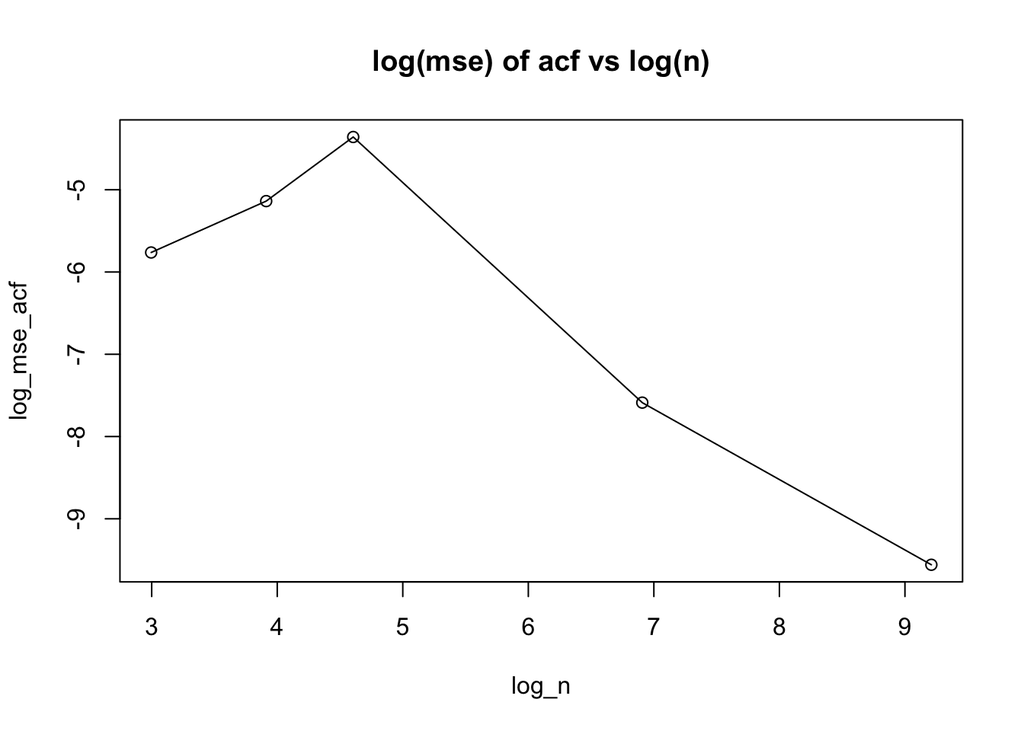

```r
plot(log_n,log_mse_acf,type="l")
points(log_n,log_mse_acf)
title("log(mse) of acf vs log(n)")
```

```r
#log(mse) of PACF vs log(n)
print(c("log(mse) of PACF:",log_mse_pacf))
```

```
## [[1]]
## [1] "log(mse) of PACF:"
##
## [[2]]
## [1] -4.629031
##
## [[3]]
## [1] -5.09961
##
## [[4]]
## [1] -4.486624
##
## [[5]]
## [1] -7.427467
##
## [[6]]
## [1] -9.645556
```

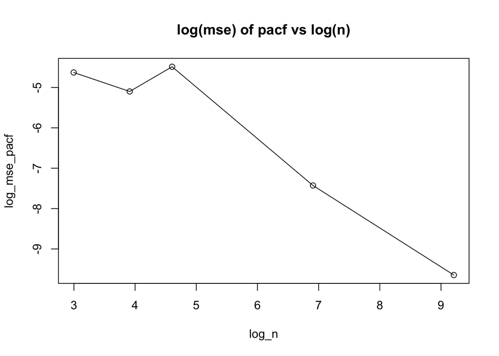

```r
plot(log_n,log_mse_pacf,type="l")
points(log_n,log_mse_pacf)
title("log(mse) of pacf vs log(n)")
```

### Investigation

From the graphs,we can see that sample acf/pacf converges fastest to their theoretical values when n increases from 100 to 1000. In general,sample acf/pacf starts converging when n is greater than 100.

In the following,we are going to try increasing phi to 0.9 and 0.99.

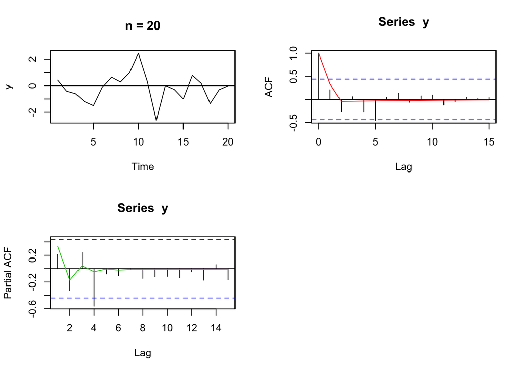

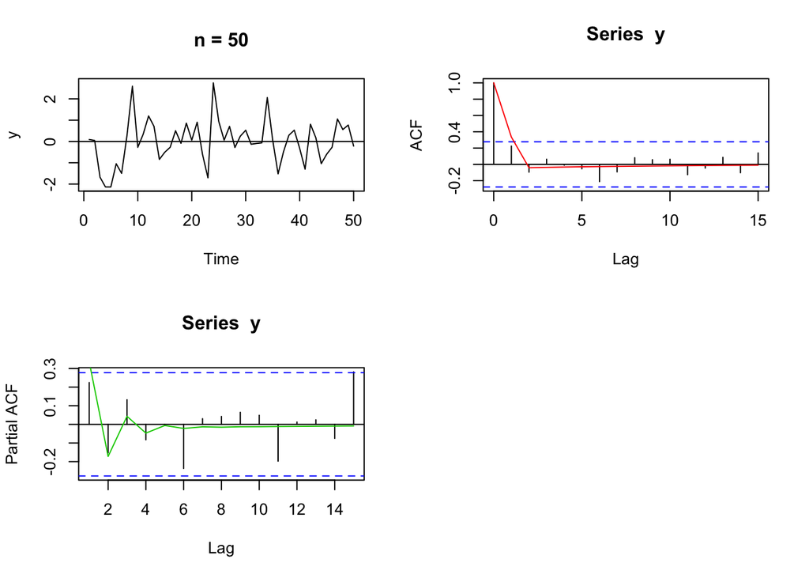

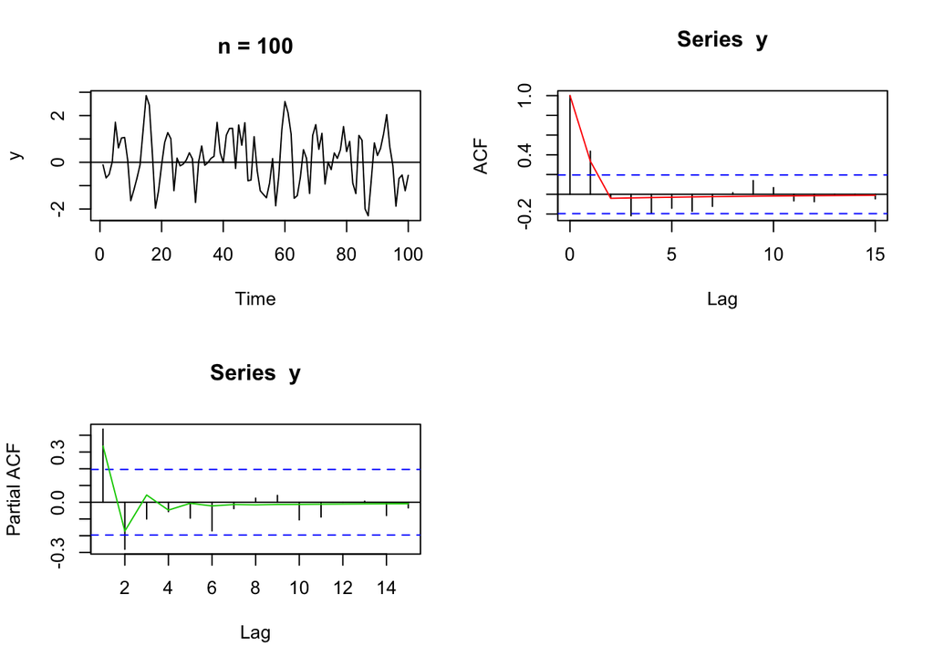

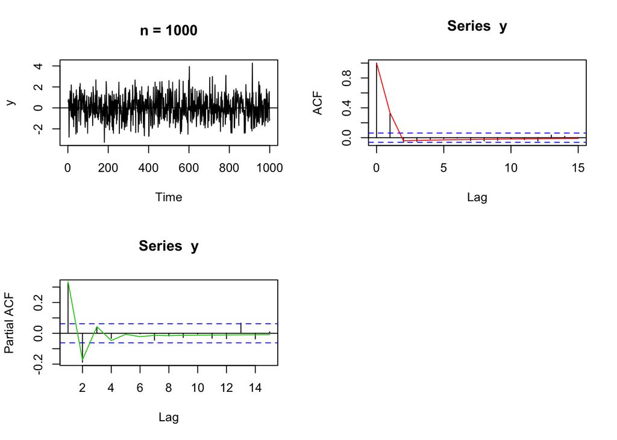

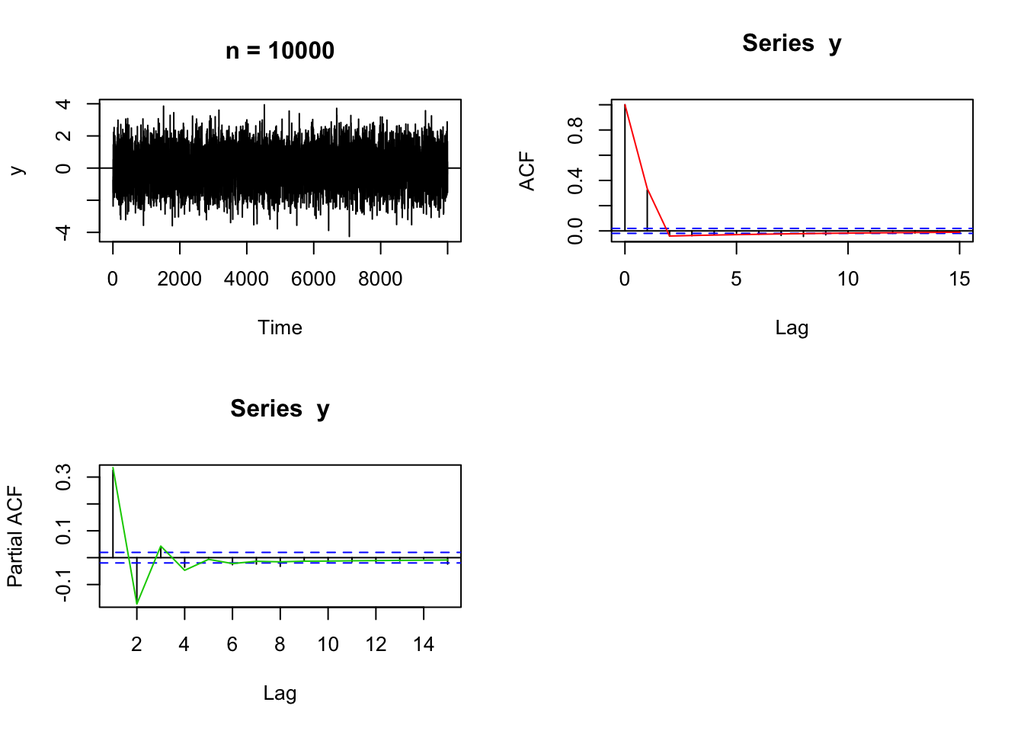

```r
#set seed to ensure all results and figures are reproducible
set.seed(123)
phi <- 0.9
theta1 <- 0.5
theta2 <- 0.4
n <- 20
σ <- 1
i<-0
#empty lists for storing values later
log_mse_acf2 <- vector(mode = "list", length = 0)
log_mse_pacf2 <- vector(mode = "list", length = 0)
mse_acf2 <- vector(mode = "list", length = 0)
mse_pacf2 <- vector(mode = "list", length = 0)
for (n in c(20 , 50, 100, 1000, 10000)){
  i <- i + 1
par(mfrow = c(2,2))
y = arima.sim(n=n, model=list( ar=c(phi), ma=-c(theta1,theta2) ) ,sd = σ)
# plot the time series
ts.plot(y)
abline(h = 0)
title(paste("n =",n))
# plot the acf
#Sample ACF
a2<-acf(y,lag.max=15)
# Generate the theoretical ACF with upto lag 15
ta2 <- ARMAacf(ar=c(phi),ma= -c(theta1,theta2),lag.max=15) #theoretical acf
lines(0:15,ta2,col=2)
# plot the pacf
#Sample PACF
p2<-pacf(y,lag.max=15)
# Generate the theoretical PACF with upto lag 15
tp2<-ARMAacf(ar=c(phi),ma= -c(theta1,theta2),lag.max=15,pacf=TRUE)
lines(1:15,tp2,col=3)
#calculate the mse of acf
msa2 <- mean( (a2$acf-ta2)**2)
#append
mse_acf2 <- c(mse_acf2,msa2)
#append(log mse so as to benefit the visualisation)
log_mse_acf2 <- c(log_mse_acf2,log(msa2))
#calculate the mse of pacf
msp2 <- mean( (p2$acf-tp2)**2)
#append
mse_pacf2 <- c(mse_pacf2,msp2)
#append(log mse so as to benefit the visualisation)
log_mse_pacf2 <- c(log_mse_pacf2,log(msp2))
}
```

```r
print(c("mean square error of ACF:",mse_acf2))
```

```
## [[1]]
## [1] "mean square error of ACF:"
##
## [[2]]
## [1] 0.02423097
##
## [[3]]
## [1] 0.008894982
##
## [[4]]
## [1] 0.009582228
##
## [[5]]
## [1] 0.0004248128
##
## [[6]]
## [1] 7.486892e-05
```

```r
print(c("mean square error of PACF:",mse_pacf2))
```

```
## [[1]]
## [1] "mean square error of PACF:"
##
## [[2]]
## [1] 0.03124299
##
## [[3]]
## [1] 0.01388403
##
## [[4]]
## [1] 0.006534121
##
## [[5]]
## [1] 0.0006671792
##
## [[6]]
## [1] 7.133626e-05
```

### Investigation

We can see that at the when n is getting larger,the sample acf/pacf and theoretical acf/pacf are converging. When we compare with phi = 0.8,we notice that the differences between sample acf/pacf and the theoretical acf/pacf when n is small are greater, we can explore is phi = 0.99 also has the same results later.

Lets visualise our results.

```r
print(log_n)
```

```
## [1] 2.995732 3.912023 4.605170 6.907755 9.210340
```

```r
#Visualisation
#log(mse) of ACF vs log(n)
print(c("log(mse) of ACF:",log_mse_acf2))
```

```
## [[1]]
## [1] "log(mse) of ACF:"
##
## [[2]]
## [1] -3.720124
##
## [[3]]
## [1] -4.722268
##
## [[4]]
## [1] -4.647845
##
## [[5]]
## [1] -7.763862
##
## [[6]]
## [1] -9.499772
```

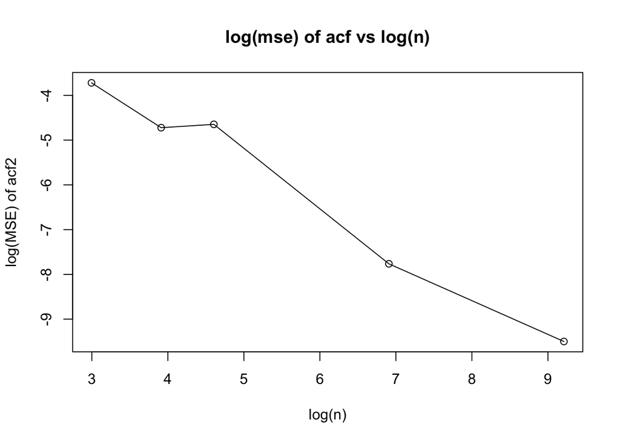

```r
plot(log_n,log_mse_acf2,type="l",xlab ="log(n)",ylab = "log(MSE) of acf2")
points(log_n,log_mse_acf2)
title("log(mse) of acf vs log(n)")
```

```r
#Visualisation
#log(mse) of PACF vs log(n)
print(c("log(mse) of PACF:",log_mse_pacf2))
```

```
## [[1]]
## [1] "log(mse) of PACF:"
##
## [[2]]
## [1] -3.46596
##
## [[3]]
## [1] -4.277016
##
## [[4]]
## [1] -5.030718
##
## [[5]]
## [1] -7.312452
##
## [[6]]
## [1] -9.548106
```

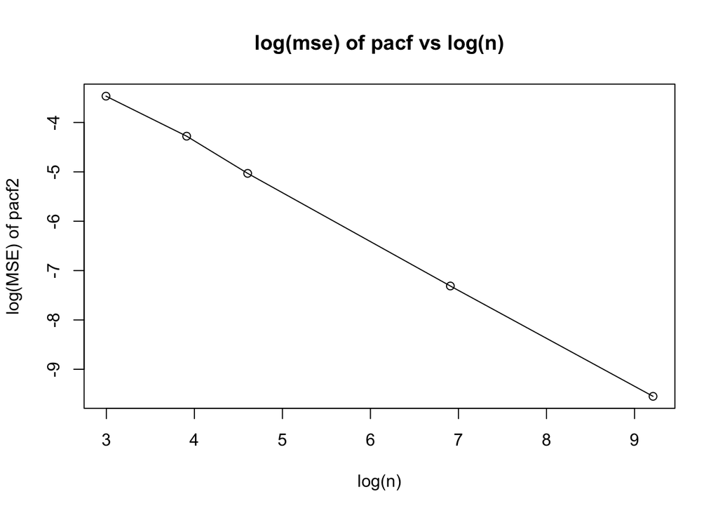

```r
plot(log_n,log_mse_pacf2,type="l",xlab ="log(n)",ylab = "log(MSE) of pacf2")
points(log_n,log_mse_pacf2)
title("log(mse) of pacf vs log(n)")
```

### Investigation

In the following,we are going to try increasing phi to 0.99.

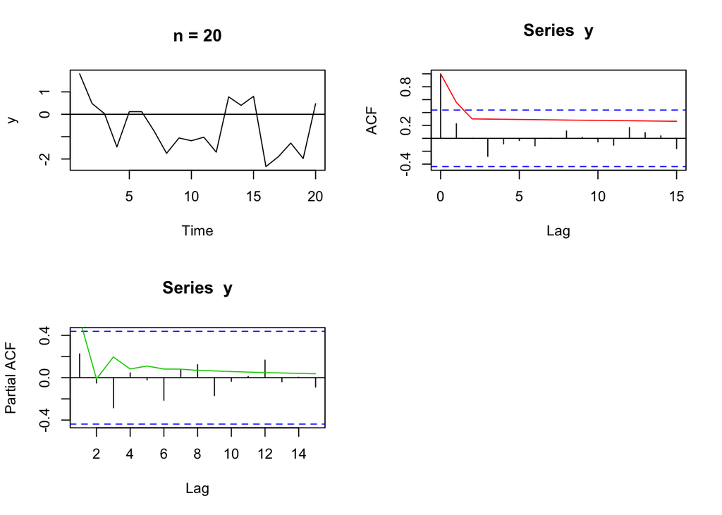

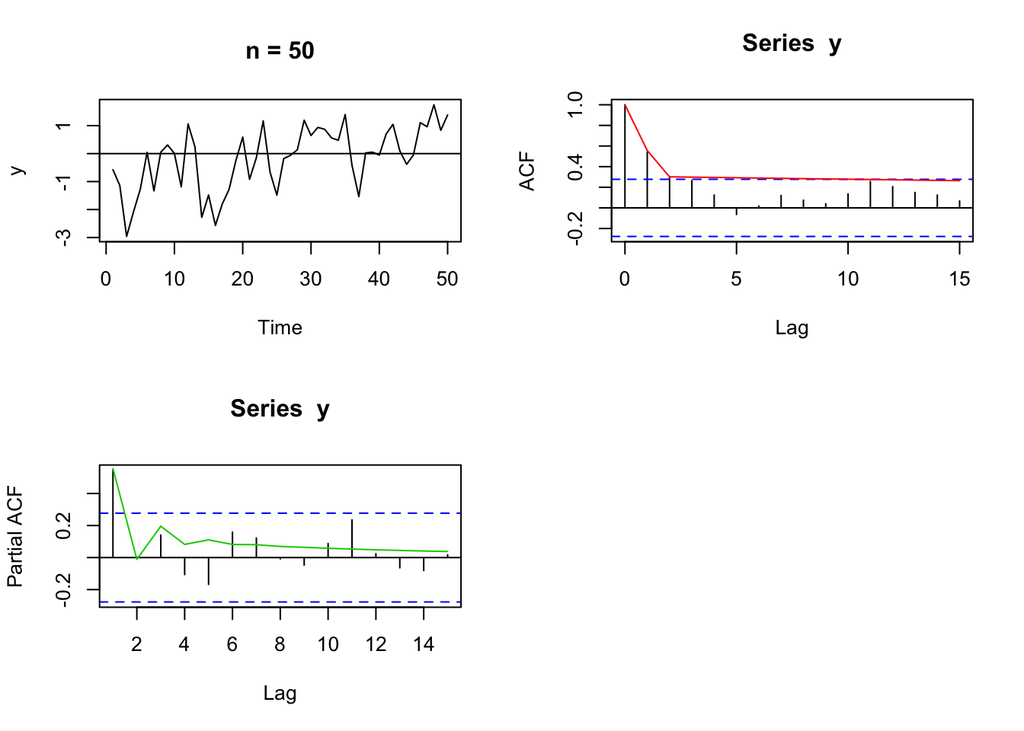

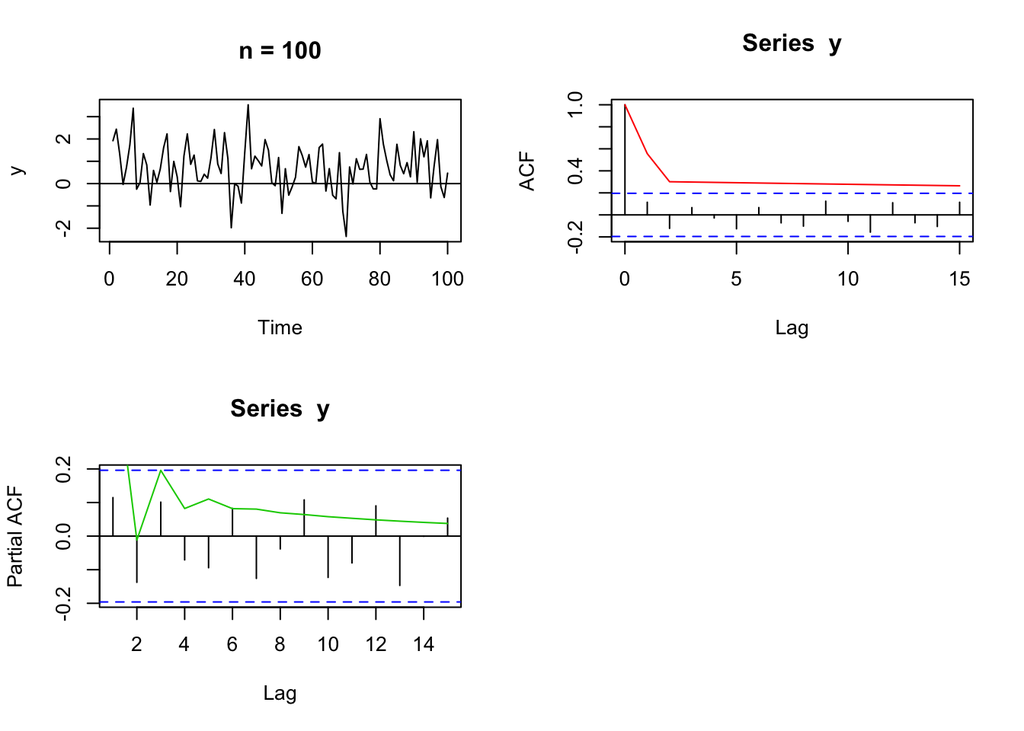

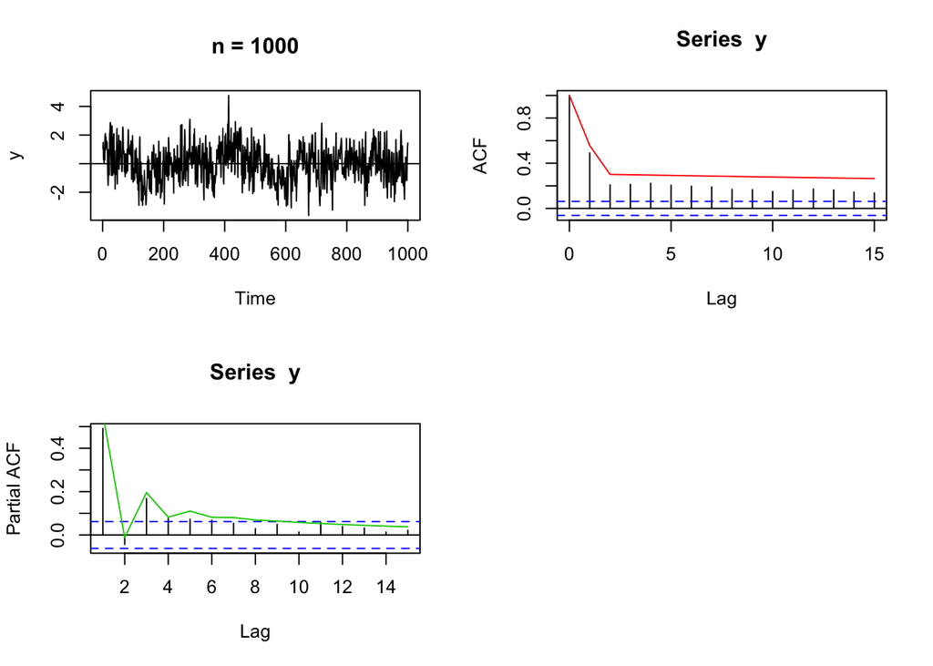

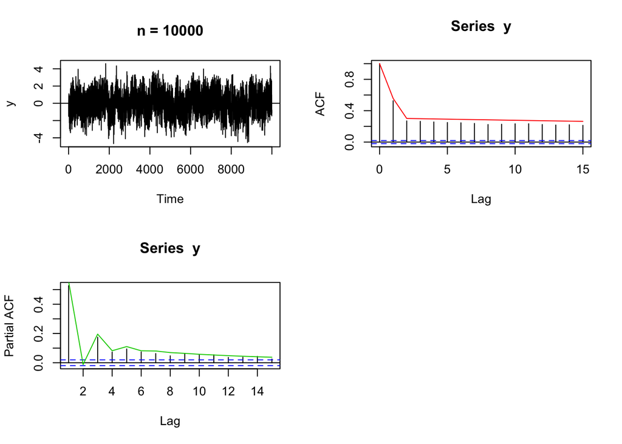

```r
#set seed to ensure all results and figures are reproducible
set.seed(123)
phi <- 0.99
theta1 <- 0.5
theta2 <- 0.4
n <- 20
σ <- 1
i<-0
#empty lists for storing values later
log_mse_acf3 <- vector(mode = "list", length = 0)
log_mse_pacf3 <- vector(mode = "list", length = 0)
mse_acf3 <- vector(mode = "list", length = 0)
mse_pacf3 <- vector(mode = "list", length = 0)
for (n in c(20 , 50, 100, 1000, 10000)){
  i <- i + 1
# Split plotting window in 2 rows and 2 columns
par(mfrow = c(2,2))
y = arima.sim(n=n, model=list( ar=c(phi), ma=-c(theta1,theta2) ),sd = σ )
# plot the time series
ts.plot(y)
abline(h = 0)
title(paste("n =",n))
# plot the acf
#Sample ACF
a3<-acf(y,lag.max=15)
# Generate the theoretical ACF with upto lag 15
ta3 <- ARMAacf(ar=c(phi),ma= -c(theta1,theta2),lag.max=15) #theoretical acf
lines(0:15,ta3,col=2)
# plot the pacf
#Sample PACF
p3<-pacf(y,lag.max=15)
# Generate the theoretical PACF with upto lag 15
tp3<-ARMAacf(ar=c(phi),ma= -c(theta1,theta2),lag.max=15,pacf=TRUE)
lines(1:15,tp3,col=3)
#calculate the mse of acf
msa3 <- mean( (a3$acf-ta3)**2)
#append
mse_acf3 <- c(mse_acf3,msa3)
#append(log mse so as to benefit the visualisation)
log_mse_acf3 <- c(log_mse_acf3,log(msa3))
#calculate the mse of pacf
msp3 <- mean( (p3$acf-tp3)**2)
#append
mse_pacf3 <- c(mse_pacf3,msp3)
#append(log mse so as to benefit the visualisation)
log_mse_pacf3 <- c(log_mse_pacf3,log(msp3))
}
```

```r
print(c("mean square error of ACF:",mse_acf3))
```

```
## [[1]]
## [1] "mean square error of ACF:"
##
## [[2]]
## [1] 0.1039013
##
## [[3]]
## [1] 0.02860961
##
## [[4]]
## [1] 0.1039842
##
## [[5]]
## [1] 0.009915359
##
## [[6]]
## [1] 0.001889267
```

```r
print(c("mean square error of PACF:",mse_pacf3))
```

```
## [[1]]
## [1] "mean square error of PACF:"
##
## [[2]]
## [1] 0.03685282
##
## [[3]]
## [1] 0.01362525
##
## [[4]]
## [1] 0.02877403
##
## [[5]]
## [1] 0.0008923458
##
## [[6]]
## [1] 0.0001881224
```

### Investigation

Lets visualise our results.

```r
#take log on both n and mse as mse is very small
print(log_n)
```

```
## [1] 2.995732 3.912023 4.605170 6.907755 9.210340
```

```r
#Visualisation
#log(mse) of ACF vs log(n)
print(c("log(mse) of ACF:",log_mse_acf3))
```

```
## [[1]]
## [1] "log(mse) of ACF:"
##
## [[2]]
## [1] -2.264314
##
## [[3]]
## [1] -3.554012
##
## [[4]]
## [1] -2.263516
##
## [[5]]
## [1] -4.61367
##
## [[6]]
## [1] -6.271566
```

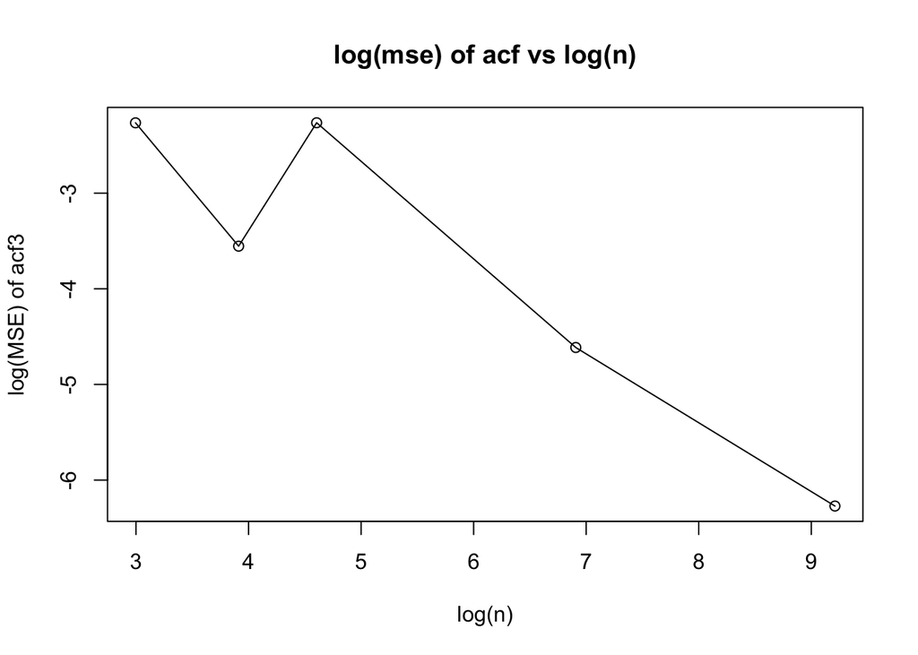

```r
plot(log_n,log_mse_acf3,type="l",xlab ="log(n)",ylab = "log(MSE) of acf3")
points(log_n,log_mse_acf3)
title("log(mse) of acf vs log(n)")
```

```r
#Visualisation
#log(mse) of PACF vs log(n)
print(c("log(mse) of PACF:",log_mse_pacf3))
```

```
## [[1]]
## [1] "log(mse) of PACF:"
##
## [[2]]
## [1] -3.300823
##
## [[3]]
## [1] -4.295831
##
## [[4]]
## [1] -3.548282
##
## [[5]]
## [1] -7.021657
##
## [[6]]
## [1] -8.578418
```

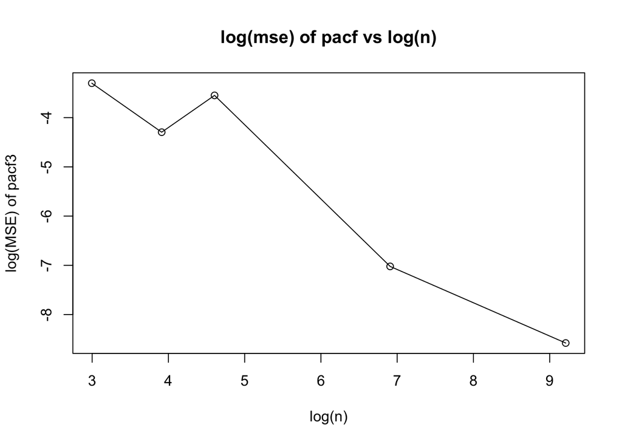

```r
plot(log_n,log_mse_pacf3,type="l",xlab ="log(n)",ylab = "log(MSE) of pacf3")
points(log_n,log_mse_pacf3)
title("log(mse) of pacf vs log(n)")
```

### Investigation

Lets take a look at all the pacf and acf together

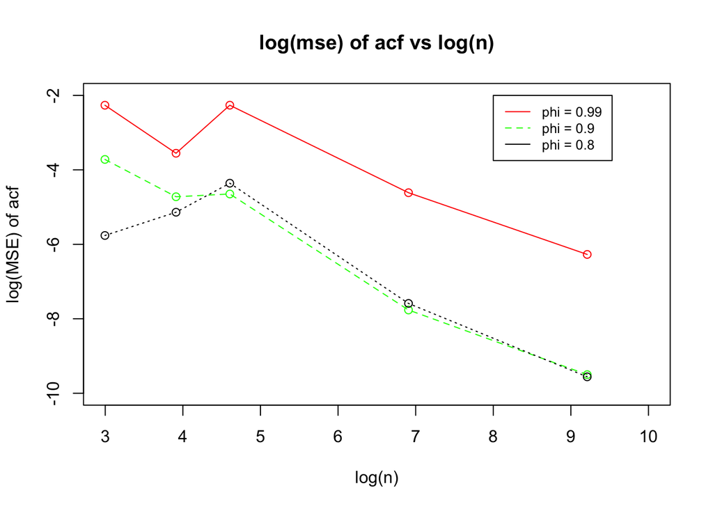

```r
#plot log(mse) of acf vs log(n)
plot(log_n,log_mse_acf3,type="l",col="red",lty = 1,xlim=c(3, 10),ylim=c(-10, -2),main = "log(mse) of acf vs log(n)",xlab ="log(n)",ylab = "log(MSE) of acf")
points(log_n,log_mse_acf3,col="red",lty = 1)

lines(log_n,log_mse_acf2,col="green" ,lty=2)
points(log_n,log_mse_acf2,col="green" ,lty=2)

lines(log_n,log_mse_acf,lty=3)
points(log_n,log_mse_acf,lty=3)
legend(8,-2, legend=c("phi = 0.99 ", "phi = 0.9 ", "phi = 0.8"),
       col=c("red", "green","black"),lty=1:2, cex=0.8)
```

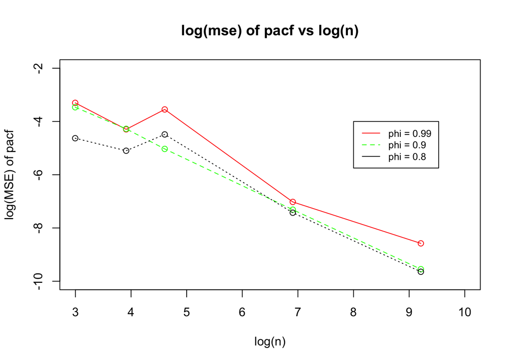

```r
#plot log(mse) of pacf vs log(n)
plot(log_n,log_mse_pacf3,type="l",col="red",lty = 1,xlim=c(3, 10),ylim=c(-10, -2),main = "log(mse) of pacf vs log(n)",xlab ="log(n)",ylab = "log(MSE) of pacf")
points(log_n,log_mse_pacf3,col="red")
lines(log_n,log_mse_pacf2,col="green" ,lty=2)
points(log_n,log_mse_pacf2,col="green" ,lty=2)
lines(log_n,log_mse_pacf,lty=3)
points(log_n,log_mse_pacf,lty=3)
legend(8,-4, legend=c("phi = 0.99 ", "phi = 0.9 ", "phi = 0.8"),
       col=c("red", "green","black"),lty=1:2, cex=0.8)
```

## Conclusion

To sum up that everything that has be stated so far,when phi has a bigger value the differences between sample acf/pacf and the theoretical acf/pacf will be greater for a small n.In addition,when phi is close to 1(phi = 0.99),the general differences are bigger than the other phi value. However, when phi = 0.9 is generally converging the fastest and surprisingly the mean square error of acf and pacf of phi = 0.9 and phi = 0.8 are very similar when n is greater than 100. In the future,we could simulate more different phi values.